# Proyecto I: Visualización de datos climáticos

Sara Alvarado Siles

### Paso 1

Cargar librerias

> library(dplyr)  
> library(ggplot2)  
> library(hrbrthemes)  
> library(ggpubr)  
> library(tidyverse)  
> library(lubridate)

```
## NOTE: Either Arial Narrow or Roboto Condensed fonts are required to use these themes.
```

```
##       Please use hrbrthemes::import_roboto_condensed() to install Roboto Condensed and
```

```
##       if Arial Narrow is not on your system, please see https://bit.ly/arialnarrow
```

### Paso 2

Importar a R los datos, organisados de forma requerida.

> datos_climaticos <- read.csv(“Liberia_datos_climaticos.csv”, na.strings = "")

### Paso 3

Visualizar los primeros datos del documento

> slice_head(datos_climaticos, n = 5)

```
##    ï..Date   Indicador Valor
## 1 1/1/2015 Temperatura 27.88
## 2 2/1/2015 Temperatura 28.06
## 3 3/1/2015 Temperatura 28.91
## 4 4/1/2015 Temperatura 28.13
## 5 5/1/2015 Temperatura 28.00
```

### Paso 4

Visualizar las dimenciones del documento

> dim(datos_climaticos)

```
## [1] 9306    3
```

Aqui hay *9306* filas y *3* columnas

### Paso 5

Comprobar si hay celdas vacias

> datos_climaticos[!complete.cases(datos_climaticos),]

```
##        ï..Date          Indicador Valor
## 1193  7/4/2018        Temperatura    NA
## 2744  7/4/2018            Humedad    NA
## 4208 10/1/2018          Velocidad    NA
## 4209 11/1/2018          Velocidad    NA
## 4210 12/1/2018          Velocidad    NA
## 4248 19/2/2018          Velocidad    NA
## 4249 20/2/2018          Velocidad    NA
## 4266  9/3/2018          Velocidad    NA
## 4267 10/3/2018          Velocidad    NA
## 4268 11/3/2018          Velocidad    NA
## 4269 12/3/2018          Velocidad    NA
## 4270 13/3/2018          Velocidad    NA
## 4271 14/3/2018          Velocidad    NA
## 4272 15/3/2018          Velocidad    NA
```

[output cut: 16 more lines]

### Paso 6

Eliminar los NA

> newdatos_climaticos <- na.omit(datos_climaticos)

### Paso 7

Comprobar que se hallan hecho los cambios

> newdatos_climaticos[!complete.cases(newdatos_climaticos),]

```
## [1] ï..Date   Indicador Valor
## <0 rows> (or 0-length row.names)
```

### Paso 8

Cambiar los nombre de las columnas mediante rename()

> newdatos_climaticos <-  
> newdatos_climaticos %>%  
> rename(fecha = ï..Date,)

### Paso 9

Conversión de una columna a tipo Date

> newdatos_climaticos <-  
> newdatos_climaticos %>%  
> mutate(fecha = as.Date(fecha, format = “%d/%m/%Y”))

### Paso 10

Ver de nuevo los datos

> str(newdatos_climaticos)

```
## 'data.frame':    9276 obs. of  3 variables:
##  $ fecha    : Date, format: "2015-01-01" "2015-01-02" ...
##  $ Indicador: chr  "Temperatura" "Temperatura" "Temperatura" "Temperatura" ...
##  $ Valor    : num  27.9 28.1 28.9 28.1 28 ...
##  - attr(*, "na.action")= 'omit' Named int [1:30] 1193 2744 4208 4209 4210 4248 4249 4266 4267 4268 ...
##   ..- attr(*, "names")= chr [1:30] "1193" "2744" "4208" "4209" ...
```

### Paso 11

Generar los histogramas de las 6 variables solicitadas

> *#Histograma en facets*  
> ggplot(newdatos_climaticos,  
> aes(x = Valor, colour = Indicador))+  
> geom_histogram() +  
> facet_wrap(~Indicador, nrow = 2, scale = “free”)+  
> ggtitle(“Datos climáticos de la estación Liberia, Guanacaste”, subtitle=“Del 1 de enero del 2015 al 31 de marzo del 2019”)+  
> xlab(“Frecuencia”) +  
> ylab(“Valores”)

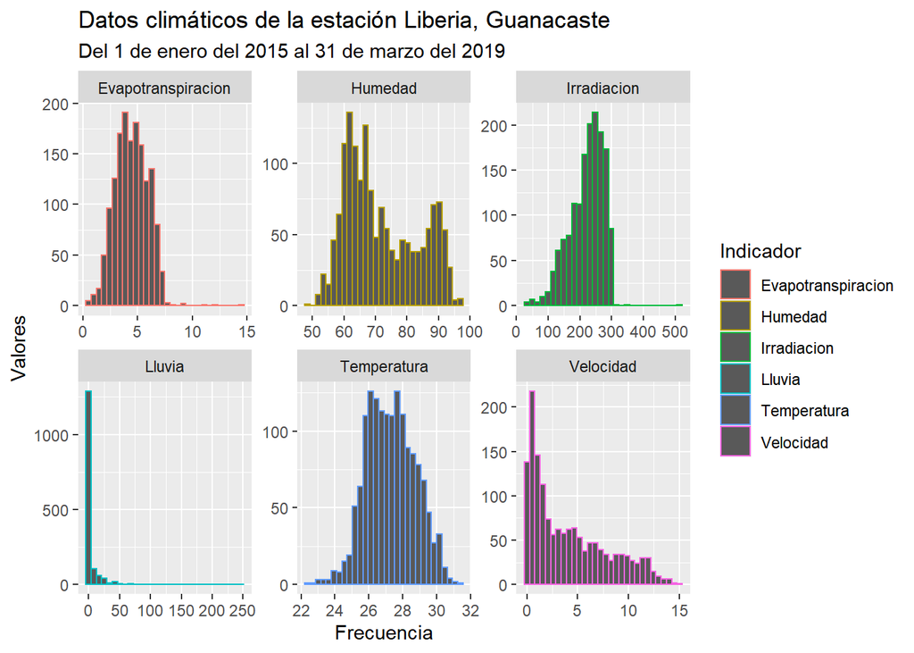

### Paso 12

Calcular promedios mensuales de la temperatura, humedad relativa, velocidad del viento e irradiacion.

> *#Calcular promedios mensuales*  
> promd <- newdatos_climaticos %>%  
> filter(Indicador == “Temperatura” | Indicador == “Humedad” | Indicador == “Velocidad” | Indicador == “Irradiacion”) %>%  
> group_by(Indicador, mes = format(fecha,“%m”) ) %>%  
> summarize(mean_1=mean(Valor))

### Paso 13

Convertir a numeros los datos

> promd$mes <- as.numeric(promd$mes)

### Paso 14

Grafico de promedios mensuales de las 4 variables solicitadas

> *#Grafico promedios mensuales*  
> ggplot(promd,  
> aes(x = mes, y = mean_1, colour = Indicador))+  
> geom_line() +  
> facet_wrap(~Indicador, nrow = 2, scale = “free”)+  
> scale_x_continuous(breaks = seq(1, 12, 1))+  
> ggtitle(“Promedios mensuales”,  
> subtitle=“Del 1 de enero del 2015 al 31 de marzo del 2019”)+  
> xlab(“Mes”) +  
> ylab(“Valores”)

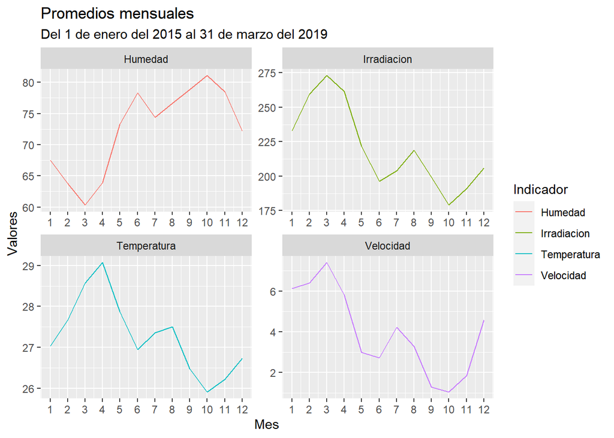

### Paso 15

Calcular la suma de lluvia y evapotranpiracion

> *#Calcular suma*  
> suma <- newdatos_climaticos %>%  
> filter(Indicador == “Lluvia” | Indicador == “Evapotranspiracion”) %>%  
> group_by(Indicador, mes = format(fecha,“%m”) ) %>%  
> summarize(sum_1=sum(Valor))

### Paso 16

Combertir a numeros los datos

> suma$mes <- as.numeric(suma$mes)

### Paso 17

Crear un grafico de la suma de lluvia y evapotranspiracion

> *#Grafico de la suma*  
> ggplot(suma,  
> aes(x = mes, y = sum_1, colour = Indicador))+  
> geom_line() +  
> facet_wrap(~Indicador, nrow = 2, scale = “free”)+  
> scale_x_continuous(breaks = seq(1, 12, 1))+  
> ggtitle(“Suma de valores de la lluvia y evapotranspiracion en la estacion Liberia”,  
> subtitle=“Del 1 de enero del 2015 al 31 de marzo del 2019”)+  
> xlab(“Mes”) +  
> ylab(“Valores”)

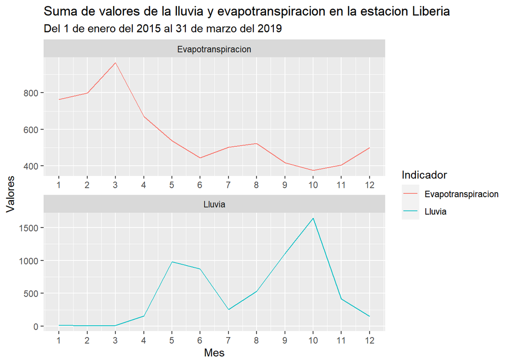

### Paso 18

Grafico de nube de puntos de las 6 variables

> *#Grafico de nube de puntos*  
> ggplot(newdatos_climaticos,  
> aes(x = fecha, y = Valor, colour = Indicador))+  
> geom_point() +  
> facet_wrap(~Indicador, nrow = 2, scale = “free”)+  
> ggtitle(“Valores de la suma de lluvia y evapotranspiracion”,  
> subtitle=“Del 1 de enero del 2015 al 31 de marzo del 2019”)+  
> xlab(“Años”) +  
> ylab(“Valores”)

[figure not shown]

### Paso extra

PD: Profe, en el proceso de buscar como hacer los graficos encontre esta forma y se ve bonito, entonces quiece ponerlo como un paso extra. Muchas Gracias

> p1 <- ggplot(newdatos_climaticos,  
> aes(x = fecha, y = Valor, colour = Indicador))+  
> geom_point() +  
> facet_wrap(~Indicador, nrow = 2, scale = “free”)+  
> ggtitle(“Datos climáticos de la estación Liberia, Guanacaste”)

> p2 <- ggplot(newdatos_climaticos,  
> aes(x = Valor, colour = Indicador))+  
> geom_histogram() +  
> facet_wrap(~Indicador, nrow = 2, scale = “free”,  
> subtitle=“Del 1 de enero del 2015 al 31 de marzo del 2019”)+  
> xlab(“Valores”) +  
> ylab(“Frecuencia”)

Para ejecutarlo

> ggarrange(p1, p2, nrow = 2)

[figure not shown]